# Course Project Description

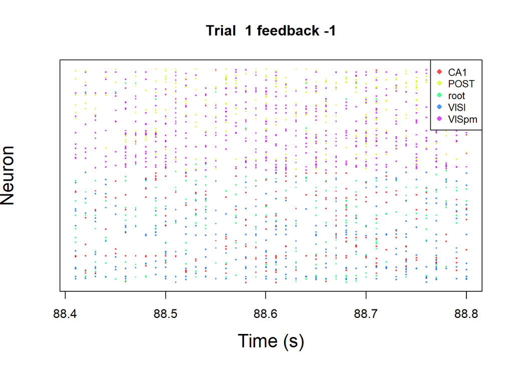

```r
plot.trial<-function(i.t,area, area.col,this_session){

    spks=this_session$spks[[i.t]];
    n.neuron=dim(spks)[1]
    time.points=this_session$time[[i.t]]

    plot(0,0,xlim=c(min(time.points),max(time.points)),ylim=c(0,n.neuron+1),col='white', xlab='Time (s)',yaxt='n', ylab='Neuron', main=paste('Trial ',i.t, 'feedback', this_session$feedback_type[i.t] ),cex.lab=1.5)
    for(i in 1:n.neuron){
        i.a=which(area== this_session$brain_area[i]);
        col.this=area.col[i.a]

        ids.spike=which(spks[i,]>0) # find out when there are spikes
        if( length(ids.spike)>0 ){
            points(x=time.points[ids.spike],y=rep(i, length(ids.spike) ),pch='.',cex=2, col=col.this)
        }


    }

legend("topright",
  legend = area,
  col = area.col,
  pch = 16,
  cex = 0.8
  )
  }
varname=names(trial.summary);
area=varname[1:(length(varname)-4)]
plot.trial(1,area, area.col,session[[i.s]])
```

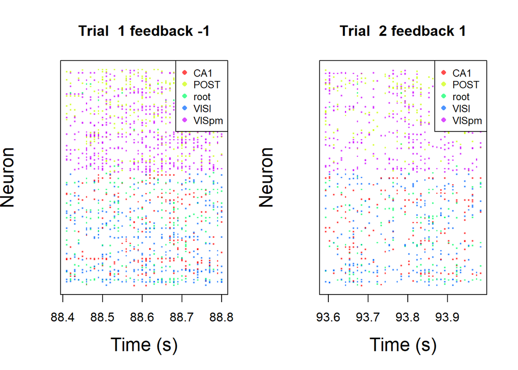

```r
varname=names(trial.summary);
area=varname[1:(length(varname)-4)]
par(mfrow=c(1,2))
plot.trial(1,area, area.col,session[[i.s]])
plot.trial(2,area, area.col,session[[i.s]])
```

```r
par(mfrow=c(1,1))
```

Part (ii) explores the neural activities during each trial. It selects a session and trial index for analysis and extracts the spike trains (neural activity data) for that particular trial. By visualizing and analyzing the neural activities, I saw insights into the patterns, dynamics, and characteristics of the neuronal responses to the stimuli presented during the trials.

(iii)explore across trials

```r
# Assuming you have a data frame called 'trial_data' containing trial-wise data
# Assuming you have a list called 'my_list' containing the data

# Convert list matrix to data frame
my_data_frame <- as.data.frame(do.call(rbind, session))
```

4. explore homogeneity and heterogeneity across sessions and mice.

Explore homogeneity and heterogeneity across sessions and mice: This part involves exploring the homogeneity and heterogeneity across different sessions and mice. By compare and contrast the data characteristics, such as the number of neurons, number of trials, and stimuli conditions, across different sessions and mice, helps identify any similarities or differences in the data across sessions or mice, which can provide valuable insights into the generalizability or uniqueness of the observed patterns or behaviors.

Part 2 (15 points). Data integration. Using the findings in Part 1, we will propose an approach to combine data across trials by (i) extracting the shared patters across sessions and/or (ii) addressing the differences between sessions. The goal of this part is to enable the borrowing of information across sessions to enhance the prediction performance in Part 3.

```r
# Combine spike train data across sessions
combined_spks <- do.call(rbind, lapply(session[1], function(s) s$spks))

# Check the structure and dimensions of combined_spks
str(combined_spks)
```

```
## List of 114
##  $ : num [1:734, 1:40] 0 0 0 0 0 0 0 0 0 0 ...
##  $ : num [1:734, 1:40] 0 0 0 0 0 0 0 0 0 0 ...
##  $ : num [1:734, 1:40] 0 0 0 0 0 0 0 0 0 0 ...
##  $ : num [1:734, 1:40] 0 0 0 0 0 0 0 0 0 0 ...
##  $ : num [1:734, 1:40] 0 0 0 0 0 0 0 0 0 0 ...
##  $ : num [1:734, 1:40] 0 0 0 0 0 0 0 0 0 0 ...
##  $ : num [1:734, 1:40] 0 0 0 0 0 0 0 0 0 0 ...
##  $ : num [1:734, 1:40] 0 0 0 0 0 0 0 0 0 0 ...
##  $ : num [1:734, 1:40] 0 0 0 0 0 0 0 0 0 0 ...
##  $ : num [1:734, 1:40] 0 0 0 0 0 0 0 0 0 0 ...
##  $ : num [1:734, 1:40] 0 0 0 0 0 0 0 0 0 0 ...
##  $ : num [1:734, 1:40] 0 0 0 0 0 0 0 0 0 0 ...
##  $ : num [1:734, 1:40] 0 0 0 0 0 0 0 0 0 0 ...
##  $ : num [1:734, 1:40] 0 0 0 0 0 0 0 0 0 0 ...
```

[output cut: 87 more lines]

```r
dim(combined_spks)
```

```
## [1]   1 114
```

```r
# Convert combined_spks to a numeric matrix
combined_spks <- matrix(unlist(combined_spks), nrow = nrow(combined_spks))

# Perform dimensionality reduction or feature extraction using PCA
pca_result <- prcomp(combined_spks)
```

```r
# Normalize or standardize the spike train data within each session
normalized_spks <- lapply(session[1], function(s) {
  # Check if the spike train data is numeric, if not convert it
  if (!is.numeric(s$spks)) {
    s$spks <- lapply(s$spks, as.numeric)  # Convert each element of spks to numeric
  }
  lapply(s$spks, scale)  # Perform normalization on each element of spks
})
```

Part 3 (15 points). Model training and prediction. Finally, we will build a prediction model to predict the outcome (i.e., feedback types). The performance will be evaluated on two test sets of 100 trials randomly selected from Session 1 and Session 18, respectively. The test sets will be released on the day of submission when you need to evaluate the performance of your model.

```r
# Combine the spike train data from the selected sessions
training_spks <- do.call(rbind, lapply(session[1], function(s) s$spks))

# Create the corresponding outcome (feedback types) vector for the training data
training_outcomes <- unlist(lapply(session[1], function(s) s$feedback_type))
```

In this step, you combine the spike train data from the selected sessions into a single matrix (training_spks). Additionally, create a corresponding outcome vector (training_outcomes) by extracting the feedback types for each session and combining them into a single vector.

```r
#population_size <- length(session)

# Set the desired sample size
#sample_size <- min(100, population_size)  # Adjust the sample size as needed

# Randomly select samples from the sessions
#sample_indices <- sample.int(population_size, sample_size, replace = FALSE)
#sample_data <- session[sample_indices]


# Combine the spike train data from the test sessions
#test_spks <- do.call(rbind, lapply(c(sample_data), function(s) s$spks))

# Create the corresponding outcome (feedback types) vector for the test data
#test_outcomes <- unlist(lapply(c(sample_data), function(s) s$feedback_type))
```

```r
# Make predictions on the test data
#predictions <- predict(model, newdata = test_spks, type = "response")

# Convert predicted probabilities to predicted classes (e.g., 1 or -1)
#predicted_classes <- ifelse(predictions > 0.5, 1, -1)

# Calculate accuracy or other performance metrics
#accuracy <- sum(predicted_classes == test_outcomes) / length(test_outcomes)
```

Use the trained model to make predictions on the test data. Convert the predicted probabilities to predicted classes based on a threshold (e.g., 0.5) and compare them with the true outcomes. Calculate performance metrics such as accuracy or other suitable metrics to evaluate the model’s performance.

# Project report outline

The final submission of the course project is a report in HTML format, along with a link to the Github repository that can be used to reproduce your report. The project report must be legible and the exposition of the report is part of the grading rubrics. For consistency in grading, please follow the outline listed below.

  The goal of this project is to create a prediction model that, using the recorded neural activity, can precisely forecast the result (kind of feedback) of each trial. We seek to elucidate the connections between brain activity patterns and trial outcomes by utilizing the data stored in the neurons’ spike trains. This predictive model may have consequences for our understanding of how decisions are underpinned by our neural systems and may help us design neural prosthetics and treatments for visual diseases. We will conduct exploratory data analysis to understand the data structures across sessions, define brain activity during each trial, investigate variations between trials, and evaluate homogeneity and heterogeneity across sessions and mice in order to accomplish our goal. With the help of this study, we will be able to comprehend the data and extract valuable features for prediction modeling.

  To merge data from several trials, we will also provide a data integration strategy. To improve the prediction performance, this will entail locating shared patterns between sessions and addressing session-specific issues. We seek to increase the precision and generalizability of our predictive model by utilizing the collective wisdom from several trials and sessions.

  Using the combined data, we will create a prediction model at the project’s final phase. Two test sets randomly chosen from Sessions 1 and 18 will be used to evaluate the model’s performance after it has been trained on a subset of trials. This assessment will shed light on the model’s generalizability to new data and overall predictive power.

  Through this project, we aim to contribute to the understanding of how neuronal activity in the visual cortex relates to trial outcomes and demonstrate the potential of predictive modeling in decoding neural activity patterns.

# Project milestones

A series of milestones are set throughout the quarter in order to encourage, and reward, early starts on the course project. Furthermore, there are several project consulting sessions throughout the quarter for students to utilize.

- Project proposal April 21st (optional): 0 points. Students are **strongly recommended** to attend the project consulting session on April 21st during the regular lecture time on Zoom.
- Milestone I May 5th (optional): 0 points but eligible for bonus points for outstanding progress or novel findings. Draft analysis and results for Part I visualization. Students are **recommended** to attend the optional project consulting on May 5th during the regular lecture time on Zoom.
- Milestone II May 26 (optional): 0 points but eligible for bonus points for outstanding progress or novel findings. Draft analysis and results for Part II data integration. Students are **recommended** to attend the optional project consulting on May 26th during the regular lecture time on Zoom.
- June 12th Project report: 45 points. Students are **strongly recommended** to attend at least one project consulting session in Week 10.

**Remark**: One important thing to note is that a course project is not an exam where questions on the exam are kept confidential. Instead, the instructor and TAs are more than happy to share with you our thoughts on how to improve your projects before you submit them. From a practical perspective, it is more rewarding to solicit advice and suggestions before we grade your reports than to wait for feedback afterwards. That said, we understand that you may have other courses and obligations that are more important than this course. Therefore, all submissions and attendance are optional except for the final project report due on June 12th.

# Reference

Steinmetz, N.A., Zatka-Haas, P., Carandini, M. et al. Distributed coding of choice, action and engagement across the mouse brain. Nature 576, 266–273 (2019). https://doi.org/10.1038/s41586-019-1787-x